# Lab_8

Gabriel Eguino

05/15/2021

### Instructions

**For each question below, show code.** Once you’ve completed things, don’t forget to to upload this document (knitted version please!) to Blackboard!

A few tips:

- Don’t forget to knit your document frequently!
- Don’t forget to `install.packages()` and load them using `library()`.
- Don’t forget to use `?` or `help()` if you’re unsure about a function
- **EXPLAIN WHAT YOUR RESULTS MEAN!** Think about the numbers and visualizations and explain, in words, what they mean.
- Make sure you label all axes and legends and add a title to your plots and maps.

**25 points total + 2 points extra-credit**

**1. Use `tidycensus` to download 1. race/ethnicity (B03002) and 2. median household income for Baltimore City. Store this data in a new object. Choose which race/ethnicity you’d like to relate to income (Non-Hispanic Black and Non-Hispanic White work best). Which census tract has the highest *percentage* of your target race/ethnicity (and what is the percent) and which has the highest median household income (and how much is it?)? (5 points)** Reminder: Since we will be mapping our data, make sure you include use `geometry = TRUE` in `get_acs()`

```r
#Variable set to view table of census data
#v17 <- load_variables(2019, "acs5", cache = TRUE)
#view(v17)

#This object retains information on Non-Hispanic Black people and their median household income
bmore_black_mhh_2019 <- get_acs(geography = "tract",
     variables = c("black_pop" = "B02009_001", #Black population
       "total_pop" = "B01003_001", #Total population
       "med_houshold_income" = "B19013_001" # Median household income
                   ),
     year = 2019,
     survey = "acs5",
     state = c(24),
     county = c(510),
     geometry = TRUE,
     output = "wide")
#Variable that retains population density of black people in Baltimore City
bmore_black_mhh_2019$percent_black_pop <- (bmore_black_mhh_2019$black_popE / bmore_black_mhh_2019$total_popE)

#Function to determine census tract ID number with the highest black population density
which.max(bmore_black_mhh_2019$percent_black_pop)
```

```
## [1] 170
```

```r
#170 produced by function
bmore_black_mhh_2019[170,]
```

```
## Simple feature collection with 1 feature and 9 fields
## geometry type:  MULTIPOLYGON
## dimension:      XY
## bbox:           xmin: -76.69009 ymin: 39.29388 xmax: -76.67046 ymax: 39.30658
## geographic CRS: NAD83
##           GEOID                                           NAME black_popE
## 170 24510160802 Census Tract 1608.02, Baltimore city, Maryland       3358
##     black_popM total_popE total_popM med_houshold_incomeE med_houshold_incomeM
## 170        374       3368        374                42547                 4269
##                           geometry percent_black_pop
## 170 MULTIPOLYGON (((-76.68948 3...         0.9970309
```

```r
#Result:'Census Tract 1608.02, Baltimore city, Maryland'

#Function to determine the  census tract ID number with the highestmedian household income
which.max(bmore_black_mhh_2019$med_houshold_incomeE)
```

```
## [1] 54
```

```r
#54 produced by function
bmore_black_mhh_2019[54,]
```

```
## Simple feature collection with 1 feature and 9 fields
## geometry type:  MULTIPOLYGON
## dimension:      XY
## bbox:           xmin: -76.62923 ymin: 39.33853 xmax: -76.60958 ymax: 39.35387
## geographic CRS: NAD83
##          GEOID                                           NAME black_popE
## 54 24510271102 Census Tract 2711.02, Baltimore city, Maryland       1194
##    black_popM total_popE total_popM med_houshold_incomeE med_houshold_incomeM
## 54        211       4597        501               195156                48413
##                          geometry percent_black_pop
## 54 MULTIPOLYGON (((-76.62923 3...         0.2597346
```

```r
#Result: 'Census Tract 2711.02, Baltimore city, Maryland'
```

**2. Please reproject this data to Web Mercator. (1 points)**

```r
#Transformation of projection to Web Mercator
st_transform(bmore_black_mhh_2019, 3857)
```

```
## Simple feature collection with 200 features and 9 fields
## geometry type:  MULTIPOLYGON
## dimension:      XY
## bbox:           xmin: -8539487 ymin: 4749959 xmax: -8519220 ymax: 4775128
## projected CRS:  WGS 84 / Pseudo-Mercator
## First 10 features:
##          GEOID                                           NAME black_popE
## 1  24510260202 Census Tract 2602.02, Baltimore city, Maryland       5313
## 2  24510150100    Census Tract 1501, Baltimore city, Maryland       2065
## 3  24510250303 Census Tract 2503.03, Baltimore city, Maryland        709
## 4  24510180100    Census Tract 1801, Baltimore city, Maryland       2163
## 5  24510020300     Census Tract 203, Baltimore city, Maryland        160
## 6  24510250402 Census Tract 2504.02, Baltimore city, Maryland       2759
## 7  24510150600    Census Tract 1506, Baltimore city, Maryland       2641
## 8  24510260102 Census Tract 2601.02, Baltimore city, Maryland       4254
```

[output cut: 24 more lines]

**3. Create two plots. In the first plot highlight the tract with the highest concentration of your selected race/eth. In the second plot highlight the tract with the highest median household income? (5 points)**

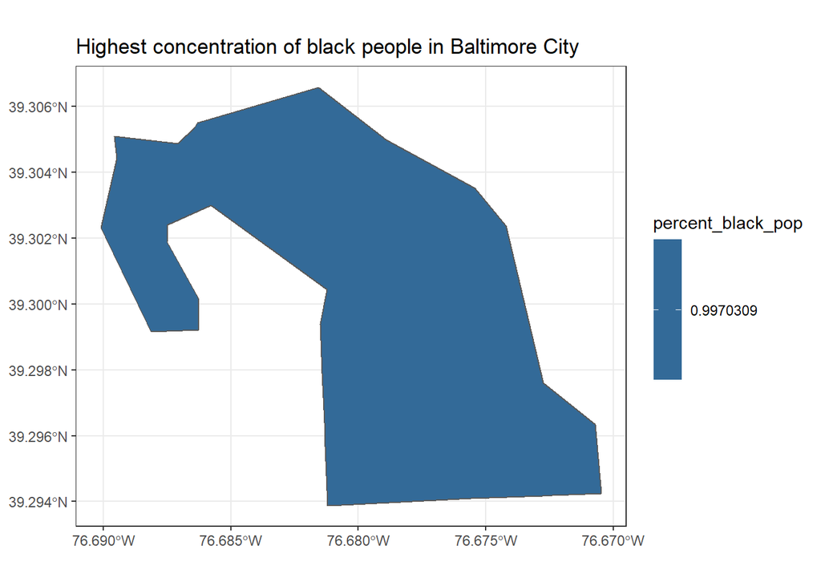

```r
#Plot with the highest concentration of black people
bmore_black_mhh_2019 %>%
  filter(GEOID == "24510160802")%>%
  ggplot() +
  geom_sf(aes(fill = percent_black_pop)) +
  labs(title = "Highest concentration of black people in Baltimore City") +
  theme_bw()
```

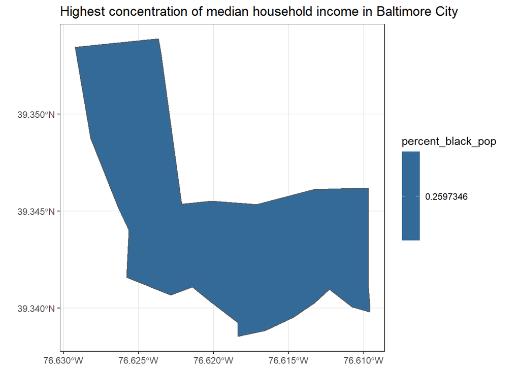

```r
#Plot with the highest median household income
bmore_black_mhh_2019 %>%
  filter(GEOID == "24510271102")%>%
  ggplot() +
  geom_sf(aes(fill = percent_black_pop)) +
  labs(title = "Highest concentration of median household income in Baltimore City") +
  theme_bw()
```

**4. Create a third column using the bi_class function from the tutorial. (2 points)**

```r
#Filtering out NA values from the tables
bmore_black_mhh_2019_clean <-na.omit(bmore_black_mhh_2019)
#view(bmore_black_mhh_2019_clean)

#Creates third column indicative of the classes the data lies in (ex. 1-3 0r 2-1)
bmore_data <- bi_class(bmore_black_mhh_2019_clean, x = percent_black_pop, y = med_houshold_incomeE, style = "quantile", dim = 3)

#plot(bmore_data)
```

**5. Create a bivariate map with your data. (3 points)**

```r
#Set data to bmore_data that captures all three needed columns
map <- ggplot(bmore_data) +
  geom_sf(mapping = aes(fill = bi_class), color = "white", size = 0.1, show.legend = FALSE) +
  bi_scale_fill(pal = "DkBlue", dim = 3) +
  geom_sf(data = bmore_black_mhh_2019[170,], fill = 'yellow', color = NA) +
  geom_sf(data = bmore_black_mhh_2019[54,], fill = 'green', color = NA)
  labs(
    title = "Race and Income in Baltimore City, MD",
    subtitle = "Dark Blue (DkBlue) Palette"
  ) +
  bi_theme()
```

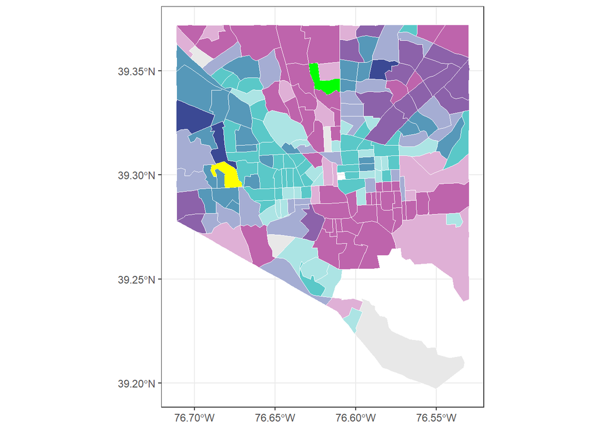

```r
plot(map)
```

**6. Use the cowplot package and ggdraw, like in the tutorial to add a legend (2 points)**.

```r
legend <- bi_legend(pal = "DkBlue",
                    dim = 3,
                    xlab = "Higher % Black",
                    ylab = "Higher Income",
                    size = 8)
```

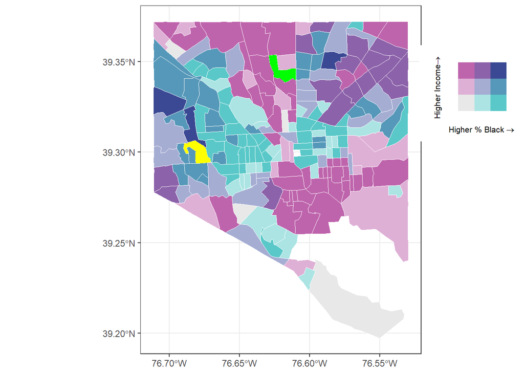

```r
finalPlot <- ggdraw() +
  draw_plot(map, 0, 0, 1, 1) +
  draw_plot(legend, .8, .5 , .2, .5)

plot(finalPlot)
```

**7. Rinse and repeat for another county of your choosing, using a *different* color scheme. Be sure to use Psuedo-Mercator (3857). (5 points)**

**Gathering neccesary data from Baltimore County

```r
#This object retains information on Non-Hispanic Black people and their median household income
bmorecounty_black_mhh_2019 <- get_acs(geography = "tract",
     variables = c("black_pop" = "B02009_001", #Black population
       "total_pop" = "B01003_001", #Total population
       "med_houshold_income" = "B19013_001" # Median household income
                   ),
     year = 2019,
     survey = "acs5",
     state = c(24),
     county = c(5),
     geometry = TRUE,
     output = "wide")
```

**Determining tracts with highest black population densisty in Baltimore County as well as the tract with the highest household median income in Baltimore County**

```r
#Variable that retains population density of black people in Baltimore County
bmorecounty_black_mhh_2019$percent_black_pop <- (bmorecounty_black_mhh_2019$black_popE / bmorecounty_black_mhh_2019$total_popE)

#Function to determine census tract ID number with the highest black population density
which.max(bmorecounty_black_mhh_2019$percent_black_pop)
```

```
## [1] 172
```

```r
#172 produced by function
bmorecounty_black_mhh_2019[172,]
```

```
## Simple feature collection with 1 feature and 9 fields
## geometry type:  MULTIPOLYGON
## dimension:      XY
## bbox:           xmin: -76.74567 ymin: 39.33179 xmax: -76.72777 ymax: 39.34929
## geographic CRS: NAD83
##           GEOID                                             NAME black_popE
## 172 24005402304 Census Tract 4023.04, Baltimore County, Maryland       3452
##     black_popM total_popE total_popM med_houshold_incomeE med_houshold_incomeM
## 172        569       3728        478                59856                21822
##                           geometry percent_black_pop
## 172 MULTIPOLYGON (((-76.74567 3...         0.9259657
```

```r
#Result:'Census Tract 4023.04, Baltimore County, Maryland'

#Function to determine the  census tract ID number with the highestmedian household income
which.max(bmorecounty_black_mhh_2019$med_houshold_incomeE)
```

```
## [1] 189
```

```r
#189 produced by function
bmorecounty_black_mhh_2019[189,]
```

```
## Simple feature collection with 1 feature and 9 fields
## geometry type:  MULTIPOLYGON
## dimension:      XY
## bbox:           xmin: -76.74014 ymin: 39.44147 xmax: -76.6854 ymax: 39.49578
## geographic CRS: NAD83
##           GEOID                                             NAME black_popE
## 189 24005408303 Census Tract 4083.03, Baltimore County, Maryland        221
##     black_popM total_popE total_popM med_houshold_incomeE med_houshold_incomeM
## 189        238       3270        149               227321                44214
##                           geometry percent_black_pop
## 189 MULTIPOLYGON (((-76.73997 3...         0.0675841
```

```r
#Result: 'Census Tract 4083.03, Baltimore County, Maryland'
```

**Projecting this data to Web Mercator**

```r
#Transformation of projection to Web Mercator
st_transform(bmorecounty_black_mhh_2019, 3857)
```

```
## Simple feature collection with 214 features and 9 fields
## geometry type:  MULTIPOLYGON
## dimension:      XY
## bbox:           xmin: -8559975 ymin: 4749701 xmax: -8496062 ymax: 4825511
## projected CRS:  WGS 84 / Pseudo-Mercator
## First 10 features:
##          GEOID                                             NAME black_popE
## 1  24005408601 Census Tract 4086.01, Baltimore County, Maryland        100
## 2  24005490703 Census Tract 4907.03, Baltimore County, Maryland        442
## 3  24005430104 Census Tract 4301.04, Baltimore County, Maryland        282
## 4  24005491000    Census Tract 4910, Baltimore County, Maryland         34
## 5  24005404102 Census Tract 4041.02, Baltimore County, Maryland       2702
## 6  24005452500    Census Tract 4525, Baltimore County, Maryland         97
## 7  24005408800    Census Tract 4088, Baltimore County, Maryland        272
## 8  24005450400    Census Tract 4504, Baltimore County, Maryland        273
```

[output cut: 24 more lines]

**Plotting tract with highest concentration of black people in Baltimore County as well as tract with the highest median household income in Baltimore County**

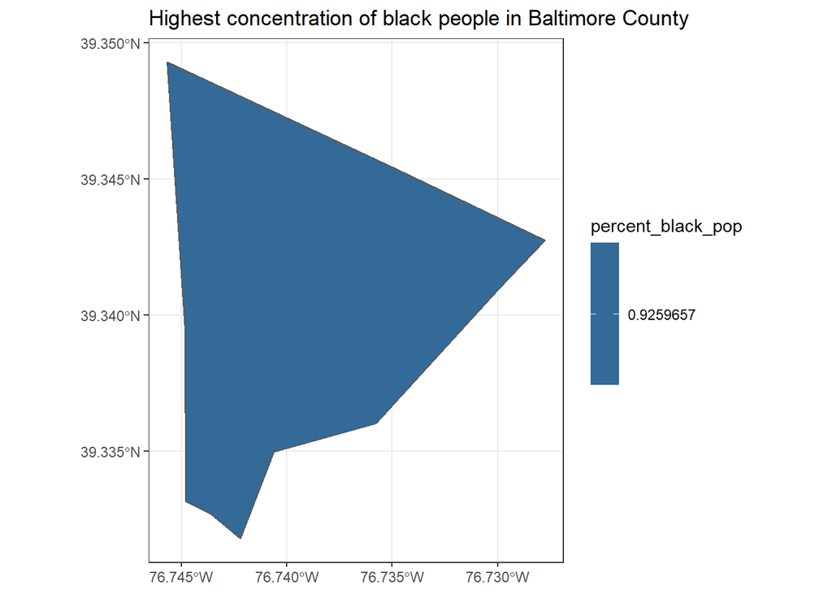

```r
#Plot with the highest concentration of black people
bmorecounty_black_mhh_2019 %>%
  filter(GEOID == "24005402304")%>%
  ggplot() +
  geom_sf(aes(fill = percent_black_pop)) +
  labs(title = "Highest concentration of black people in Baltimore County") +
  theme_bw()
```

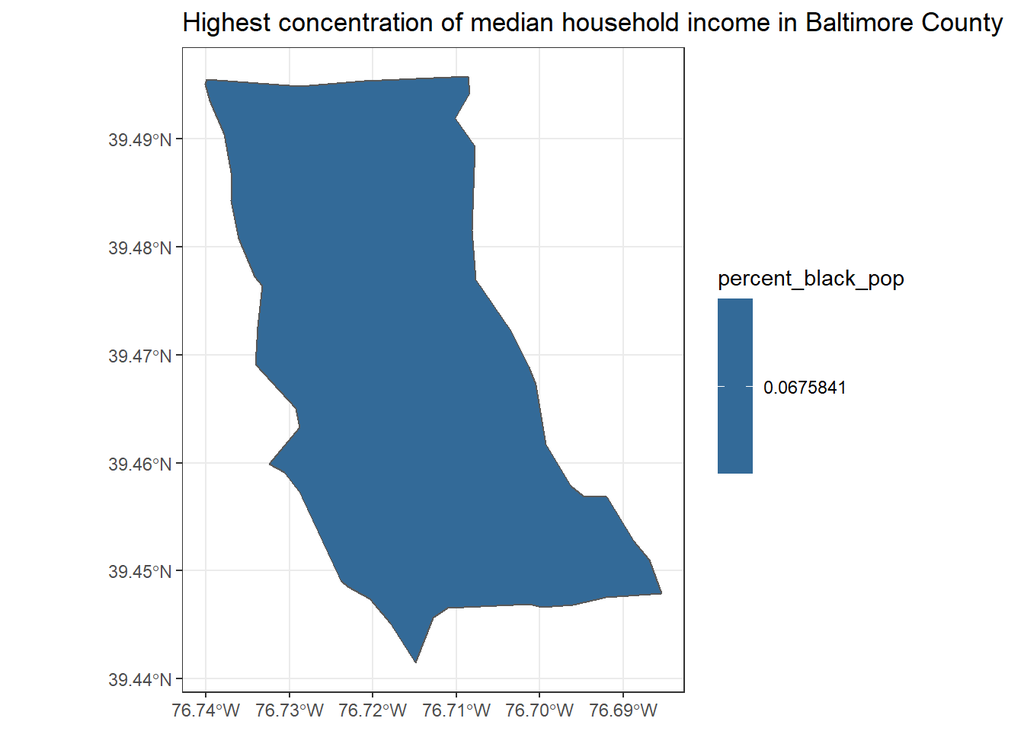

```r
#Plot with the highest median household income
bmorecounty_black_mhh_2019 %>%
  filter(GEOID == "24005408303")%>%
  ggplot() +
  geom_sf(aes(fill = percent_black_pop)) +
  labs(title = "Highest concentration of median household income in Baltimore County") +
  theme_bw()
```

**Creating a third column using the bi_class function from the tutorial**

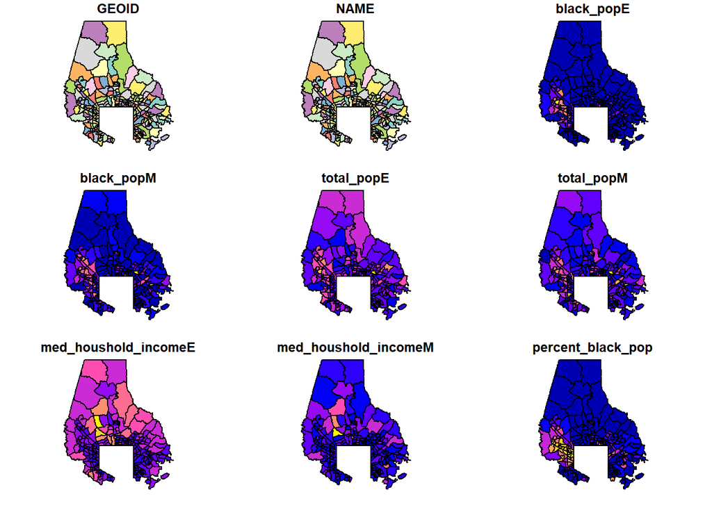

```r
#Filtering out NA values from the tables
bmorecounty_black_mhh_2019_clean <-na.omit(bmorecounty_black_mhh_2019)
#view(bmorecounty_black_mhh_2019_clean)

#Creates third column indicative of the classes the data lies in (ex. 1-3 0r 2-1)
bmorecounty_data <- bi_class(bmorecounty_black_mhh_2019_clean, x = percent_black_pop, y = med_houshold_incomeE, style = "quantile", dim = 3)

plot(bmorecounty_data)
```

```r
#Set data to bmore_data that captures all three needed columns
bmore_county_map <- ggplot(bmorecounty_data) +
  geom_sf(mapping = aes(fill = bi_class), color = "white", size = 0.1, show.legend = FALSE) +
  bi_scale_fill(pal = "DkViolet", dim = 3) +
  geom_sf(data = bmorecounty_black_mhh_2019[172,], fill = 'yellow', color = NA) +
  geom_sf(data = bmorecounty_black_mhh_2019[189,], fill = 'green', color = NA)
  labs(
    title = "Race and Income in Baltimore County, MD",
    subtitle = "Dark Violet (DkViolet) Palette"
  ) +
  bi_theme()
```

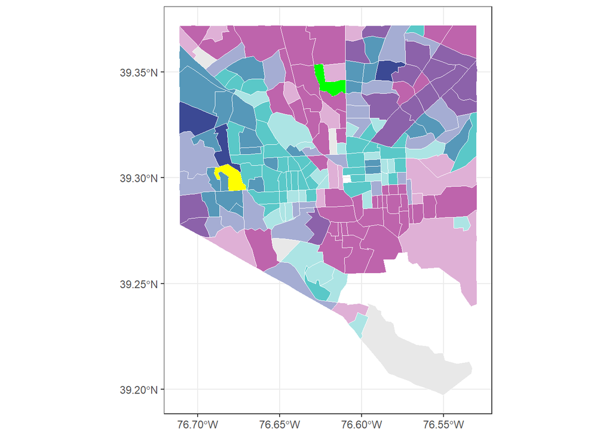

```r
plot(map)
```

** Using the cowplot package and ggdraw, like in the tutorial to add a legend**

```r
bmore_county_legend <- bi_legend(pal = "DkViolet",
                    dim = 3,
                    xlab = "Higher % Black",
                    ylab = "Higher Income",
                    size = 8)
```

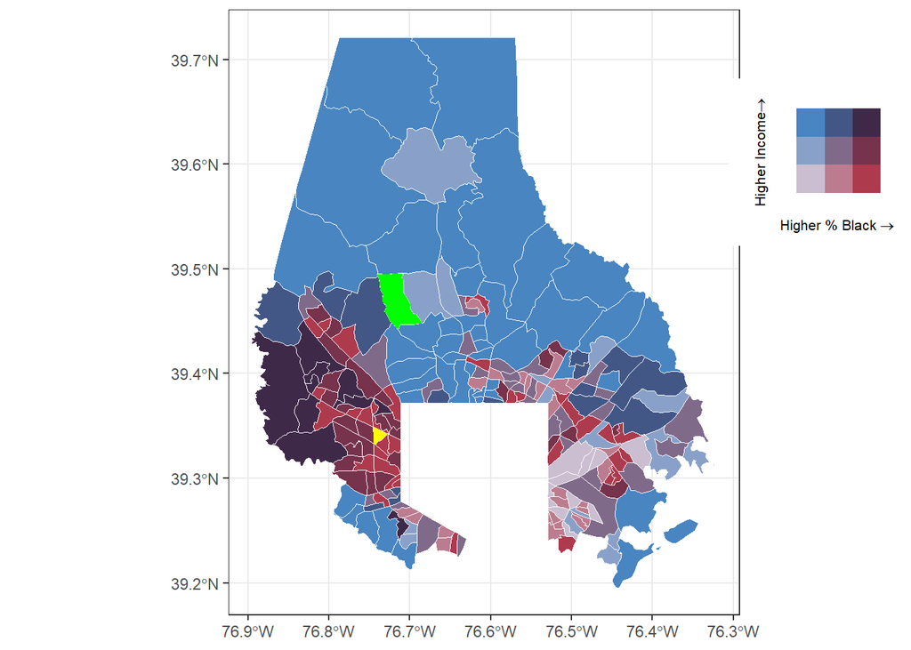

```r
finalPlot <- ggdraw() +
  draw_plot(bmore_county_map, 0, 0, 1, 1) +
  draw_plot(bmore_county_legend, .8, .5 , .2, .5)

plot(finalPlot)
```

**8. Write the bi_class output to a geojson file. (1 points)**

```r
st_write(bmore_data, "bmore_data_new.geojson")
```

```
## Writing layer `bmore_data_new' to data source `bmore_data_new.geojson' using driver `GeoJSON'
## Writing 198 features with 10 fields and geometry type Multi Polygon.
```

```r
st_write(bmorecounty_data, "bmorecounty_data_new.geojson")
```

```
## Writing layer `bmorecounty_data_new' to data source `bmorecounty_data_new.geojson' using driver `GeoJSON'
## Writing 211 features with 10 fields and geometry type Multi Polygon.
```

**9. Now open your geojson output and create a QGIS map of your bivariate map. Put an image of that map here. (2 points)**

```r
#![My Lab 8 map]("/Users/13016/Document/UMBC/Spring 2021/GES #486/Lab_8/Maps/Lab8_Bivariat/Lab8_Bivariate-1.jpg)
```

[output not shown]

**10. Use qgis2web and put a link here to your github site with the webmap of your bivariate map. (3 points)**

## 3. Reflection (3 points)

This reflection is free-form. Use this as a space to note:

- code you want to remember about this assignment
- analysis tools you want to try with your own data
- findings that arose during your data exploration that you found interesting
- or anything else you want to take away from this assignment

I learned about the importance of the bi_class function for an easier approach towards implementing dimensions in a bivariate map. I also learned how to use the na.omit function to clean my datasets from NA values that could potentially hinder the output of my map.

## 4. Extra Credit (2 points)

**Put an image as a legend in your web map.**

Knit your document to a .html file. Submit this knitted document.